# Homework 3

Levon Khachatryan

November 26, 2018

In order to avoid any cofusions, i would like to suggest you upgrade **R** version to current available version:

```r
# if (!require(installr)) { install.packages("installr"); library(installr) }
# updateR()
```

Now we can import our data set and start working with it.

```r
rm(list = ls())
dat = read.csv("D:/MyProjects/Econometrics_Homeworks/Homework_3/sources/bankloan_cs_noweights.csv", header = TRUE)
head(dat)
```

```
##   branch ncust customer age ed employ address income debtinc creddebt
## 1      3 3,017   10,012  28  2      7       2  44.00    17.7     2.99
## 2      3 3,017   10,017  64  5     34      17 116.00    14.7     5.05
## 3      3 3,017   10,030  40  1     20      12  61.00     4.8     1.04
## 4      3 3,017   10,039  30  1     11       3  27.00    34.5     1.75
## 5      3 3,017   10,069  25  1      2       2  30.00    22.4     0.76
## 6      3 3,017   10,071  35  1      2       9  38.00    10.9     1.46
##   othdebt default
## 1    4.80       0
## 2   12.00       0
## 3    1.89       0
## 4    7.56       0
## 5    5.96       1
## 6    2.68       1
```

Let’s convert the blanks (if exists) to “NA

```r
dat[dat==""]  <- NA
```

Checking and vizualization for missing values using missmap

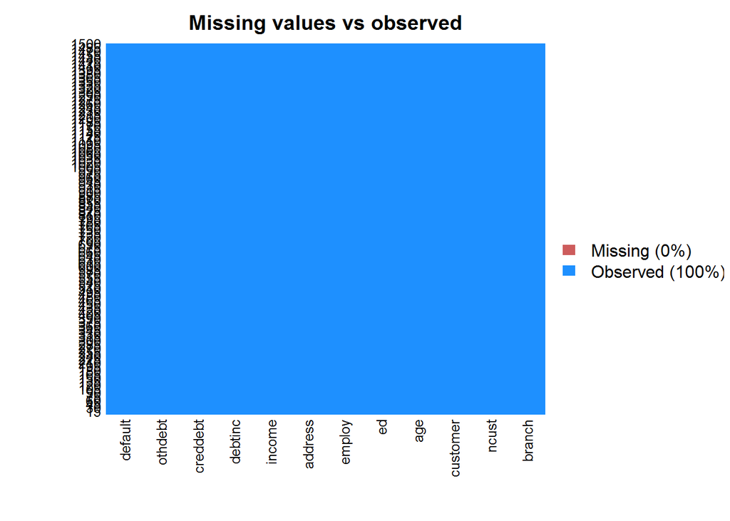

```r
library(Amelia)
missmap(dat, main = "Missing values vs observed")
```

Another way to checking for missing values using the sapply() function

```r
sapply(dat, function(x) sum(is.na(x)))
```

```
##   branch    ncust customer      age       ed   employ  address   income
##        0        0        0        0        0        0        0        0
##  debtinc creddebt  othdebt  default
##        0        0        0        0
```

Insofar as we want to see how may unique values there are for each column, we can do the following:

```r
sapply(dat, function(x) length(unique(x)))
```

```
##   branch    ncust customer      age       ed   employ  address   income
##       15       15     1500       60        5       49       33      207
##  debtinc creddebt  othdebt  default
##      273      498      703        2
```

So what we can say is that our data set has no nullable values and there are some variables (for example **ed** - education) that can be transformed to categorical. So let’s transforme **ed** to categorical variable. We can do that by the following way:

```r
dat$ed<-as.factor(dat$ed)
```

After that we can see levels by follows

```r
levels(dat$ed)
```

```
## [1] "1" "2" "3" "4" "5"
```

And the contrasts will be :

```r
contrasts(dat$ed)
```

```
##   2 3 4 5
## 1 0 0 0 0
## 2 1 0 0 0
## 3 0 1 0 0
## 4 0 0 1 0
## 5 0 0 0 1
```

In order to see the distribution of education , we can play with table (frequency table):

```r
table(dat$ed)
```

```
##
##   1   2   3   4   5
## 246 527 333 310  84
```

Let’s start the logistic regression part

## Modeling

```r
dat.small <- dat[,c("age","ed","employ","address","income","debtinc","creddebt","othdebt", "default")]
dat.small$income <- as.double(dat.small$income)
model1 <- glm(default ~ . , family=binomial(link='logit'),data=dat.small)
summary(model1)
```

```
##
## Call:
## glm(formula = default ~ ., family = binomial(link = "logit"),
##     data = dat.small)
##
## Deviance Residuals:
##     Min       1Q   Median       3Q      Max
## -3.4348  -0.7861  -0.2620   0.7573   2.5614
##
## Coefficients:
##              Estimate Std. Error z value Pr(>|z|)
## (Intercept) -0.285070   0.417785  -0.682    0.495
## age         -0.018193   0.016340  -1.113    0.266
## ed2         -0.022065   0.215388  -0.102    0.918
## ed3         -0.198672   0.233497  -0.851    0.395
## ed4          0.101601   0.241750   0.420    0.674
## ed5         -0.594862   0.363453  -1.637    0.102
## employ      -0.225975   0.022948  -9.847  < 2e-16 ***
## address     -0.031024   0.036307  -0.854    0.393
## income      -0.002579   0.001788  -1.442    0.149
## debtinc      0.101275   0.013692   7.397  1.4e-13 ***
## creddebt     0.481123   0.055102   8.732  < 2e-16 ***
## othdebt      0.019234   0.026042   0.739    0.460
## ---
## Signif. codes:  0 '***' 0.001 '**' 0.01 '*' 0.05 '.' 0.1 ' ' 1
##
## (Dispersion parameter for binomial family taken to be 1)
##
##     Null deviance: 1969.3  on 1499  degrees of freedom
## Residual deviance: 1367.6  on 1488  degrees of freedom
## AIC: 1391.6
##
## Number of Fisher Scoring iterations: 6
```

Now, as we built our logistic model, let us explain, step by step, the result of **summary** and also explain all **logic behind the logistic regression models** as well.  
The first thing which i would like to pay attention is Logistic Regression itself.  
So let us get to know the math behind it.  
It’s an extension of linear regression where the dependent variable is categorical and not continuous. It predicts the probability of the outcome variable.  
**Logistic Response Function** is the following:  
$P(y=1)=\frac{1}{1+e^-{(\beta_{0}+\beta_{1}x_{1}+\beta_{2}x_{2}+...+\beta_{k}x_{k})}}$  
The coefficients, or **$\beta$** values, are selected to maximize the likelihood of predicting a high probability for observations actually belonging to class 1 and predicting a low probability for observations actually belonging to class 0. The output of this function is always between 0 and 1.  
Positive values are predictive of class 1  
Negative values are predictive of class 0  
About **Odds Ratio** what can i say is that the odds ratio for a variable in logistic regression represents how the odds change with a 1 unit increase in that variable holding all other variables constant.  
Odds : P(y=1)/P(y=o)  
Odds > 1 if y = 1 is more likely  
Odds < 1 if y = 0 is more likely  
The Logit :  
$Odds=e^{\beta_{0} +\beta_{1}x_{1}+...+\beta_{k}x_{k}}$  
$log(Odds)=\beta_{0}+\beta_{1}x_{1}+...+\beta_{k}x_{k}$  
This is called the **“Logit”** and looks like linear regression.  
But if we are talking about logistic regression, we can not escape the following form of logistic regression :  
$y = ln(\frac{P}{1-P}) = \alpha + \beta_{1}x_{1}+ \beta_{2}x_{2}+...+\beta_{k}x_{k}$  
Now let us go back to the our logistic model . We can analyze the fitting and interpret what the model is telling us.  
Recall that the summary of our model is follows:

```r
summary(model1)
```

```
##
## Call:
## glm(formula = default ~ ., family = binomial(link = "logit"),
##     data = dat.small)
##
## Deviance Residuals:
##     Min       1Q   Median       3Q      Max
## -3.4348  -0.7861  -0.2620   0.7573   2.5614
##
## Coefficients:
##              Estimate Std. Error z value Pr(>|z|)
## (Intercept) -0.285070   0.417785  -0.682    0.495
## age         -0.018193   0.016340  -1.113    0.266
## ed2         -0.022065   0.215388  -0.102    0.918
## ed3         -0.198672   0.233497  -0.851    0.395
## ed4          0.101601   0.241750   0.420    0.674
## ed5         -0.594862   0.363453  -1.637    0.102
## employ      -0.225975   0.022948  -9.847  < 2e-16 ***
## address     -0.031024   0.036307  -0.854    0.393
## income      -0.002579   0.001788  -1.442    0.149
## debtinc      0.101275   0.013692   7.397  1.4e-13 ***
## creddebt     0.481123   0.055102   8.732  < 2e-16 ***
## othdebt      0.019234   0.026042   0.739    0.460
## ---
## Signif. codes:  0 '***' 0.001 '**' 0.01 '*' 0.05 '.' 0.1 ' ' 1
##
## (Dispersion parameter for binomial family taken to be 1)
##
##     Null deviance: 1969.3  on 1499  degrees of freedom
## Residual deviance: 1367.6  on 1488  degrees of freedom
## AIC: 1391.6
##
## Number of Fisher Scoring iterations: 6
```

In the output above, the first thing we see is the call, this is R reminding us what the model we ran was, what options we specified, etc. Next we see the deviance residuals, which are a measure of model fit. This part of output shows the distribution of the deviance residuals for individual cases used in the model. Below we discuss how to use summaries of the deviance statistic to assess model fit. The next part of the output shows the coefficients, their standard errors, the z-statistic (sometimes called a Wald z-statistic), and the associated p-values. The logistic regression coefficients give the change in the log odds of the outcome for a one unit increase in the predictor variable.  
For instance , for every one unit change in **debtinc**, the log odds of admission (versus non-admission) increases by 0.1  
The indicator variables for **ed** have a slightly different interpretation. For example, having attended an rank of 2, versus an rank of 1, changes the log odds of admission by -0.022065

We can use the confint function to obtain confidence intervals for the coefficient estimates. Note that for logistic models, confidence intervals are based on the profiled log-likelihood function. We can also get CIs based on just the standard errors by using the default method

```r
confint(model1)
```

```
##                    2.5 %        97.5 %
## (Intercept) -1.101505219  0.5384284058
## age         -0.050810159  0.0134041861
## ed2         -0.442396644  0.4029535838
## ed3         -0.655869139  0.2604491707
## ed4         -0.371167864  0.5774585505
## ed5         -1.320474227  0.1078567365
## employ      -0.272327023 -0.1822971103
## address     -0.102321689  0.0402073476
## income      -0.006083819  0.0009297393
## debtinc      0.074645513  0.1283305995
## creddebt     0.377728786  0.5933966969
## othdebt     -0.030689814  0.0709640654
```

```r
anova(model1, test="Chisq")
```

```
## Analysis of Deviance Table
##
## Model: binomial, link: logit
##
## Response: default
##
## Terms added sequentially (first to last)
##
##
##          Df Deviance Resid. Df Resid. Dev  Pr(>Chi)
## NULL                      1499     1969.3
## age       1  138.439      1498     1830.8 < 2.2e-16 ***
## ed        4   16.770      1494     1814.1  0.002142 **
## employ    1   32.950      1493     1781.1 9.454e-09 ***
## address   1    0.245      1492     1780.9  0.620770
## income    1    3.899      1491     1777.0  0.048321 *
## debtinc   1  259.825      1490     1517.2 < 2.2e-16 ***
## creddebt  1  149.038      1489     1368.1 < 2.2e-16 ***
## othdebt   1    0.555      1488     1367.5  0.456450
## ---
## Signif. codes:  0 '***' 0.001 '**' 0.01 '*' 0.05 '.' 0.1 ' ' 1
```

```r
# install.packages("pscl")
library(pscl)
pR2(model1)
```

```
##          llh      llhNull           G2     McFadden         r2ML
## -683.7771863 -984.6378103  601.7212479    0.3055546    0.3304487
##         r2CU
##    0.4520824
```

In the steps above, we briefly evaluated the fitting of the model.  
We can use stepwise model for finding best estimator for specific problem as follows:

```r
library(MASS)
step <- (stepAIC(model1, direction="backward"))
```

```
## Start:  AIC=1391.55
## default ~ age + ed + employ + address + income + debtinc + creddebt +
##     othdebt
##
##            Df Deviance    AIC
## - ed        4   1373.3 1389.3
## - othdebt   1   1368.1 1390.1
## - address   1   1368.3 1390.3
## - age       1   1368.8 1390.8
## <none>          1367.5 1391.5
## - income    1   1369.6 1391.6
## - debtinc   1   1425.4 1447.4
## - creddebt  1   1492.5 1514.5
## - employ    1   1498.3 1520.3
##
## Step:  AIC=1389.3
## default ~ age + employ + address + income + debtinc + creddebt +
##     othdebt
##
##            Df Deviance    AIC
## - othdebt   1   1373.9 1387.9
## - address   1   1374.1 1388.1
## - age       1   1374.8 1388.8
## - income    1   1375.1 1389.1
## <none>          1373.3 1389.3
## - debtinc   1   1434.0 1448.0
## - creddebt  1   1498.4 1512.4
## - employ    1   1516.6 1530.6
##
## Step:  AIC=1387.94
## default ~ age + employ + address + income + debtinc + creddebt
##
##            Df Deviance    AIC
## - address   1   1374.7 1386.7
## - age       1   1375.4 1387.4
## - income    1   1375.9 1387.9
## <none>          1373.9 1387.9
## - debtinc   1   1453.1 1465.1
## - employ    1   1522.0 1534.0
## - creddebt  1   1529.5 1541.5
##
## Step:  AIC=1386.74
## default ~ age + employ + income + debtinc + creddebt
##
##            Df Deviance    AIC
## <none>          1374.7 1386.7
## - income    1   1376.8 1386.8
## - age       1   1390.0 1400.0
## - debtinc   1   1455.5 1465.5
## - employ    1   1523.4 1533.4
## - creddebt  1   1529.5 1539.5
```

As the best estimator we can take the following model (final model)

```r
step$anova
```

```
## Stepwise Model Path
## Analysis of Deviance Table
##
## Initial Model:
## default ~ age + ed + employ + address + income + debtinc + creddebt +
##     othdebt
##
## Final Model:
## default ~ age + employ + income + debtinc + creddebt
##
##
##        Step Df  Deviance Resid. Df Resid. Dev      AIC
## 1                             1488   1367.554 1391.554
## 2      - ed  4 5.7497157      1492   1373.304 1389.304
## 3 - othdebt  1 0.6385267      1493   1373.943 1387.943
## 4 - address  1 0.7944471      1494   1374.737 1386.737
```

```r
final_model <-glm(dat.small$default ~ age + employ + income + debtinc + creddebt, data = dat.small )
summary(final_model)
```

```
##
## Call:
## glm(formula = dat.small$default ~ age + employ + income + debtinc +
##     creddebt, data = dat.small)
##
## Deviance Residuals:
##     Min       1Q   Median       3Q      Max
## -1.2166  -0.3404  -0.1112   0.3887   0.9075
##
## Coefficients:
##               Estimate Std. Error t value Pr(>|t|)
## (Intercept)  0.4748023  0.0437943  10.842  < 2e-16 ***
## age         -0.0058789  0.0012219  -4.811 1.65e-06 ***
## employ      -0.0160279  0.0018614  -8.611  < 2e-16 ***
## income      -0.0005771  0.0002397  -2.408   0.0162 *
## debtinc      0.0191314  0.0017904  10.686  < 2e-16 ***
## creddebt     0.0428922  0.0044999   9.532  < 2e-16 ***
## ---
## Signif. codes:  0 '***' 0.001 '**' 0.01 '*' 0.05 '.' 0.1 ' ' 1
##
## (Dispersion parameter for gaussian family taken to be 0.1664839)
##
##     Null deviance: 347.80  on 1499  degrees of freedom
## Residual deviance: 248.73  on 1494  degrees of freedom
## AIC: 1575.5
##
## Number of Fisher Scoring iterations: 2
```